# Enhance and Advance Introduction to R

Data Visualization Application - Gapminder Data (ANSWERS)

Eric Dunford

Summer 2020

```r
#install.packages("tidyverse")
require(tidyverse) # The tidyverse package covered last time

# install.packages("ggthemes")
require(ggthemes) # for great visualization colors and themes.

# install.packages("maps")
require(maps) # for some maps data

# Gapminder data (for example)
#install.packages("gapminder")
require(gapminder)
```

# Data

The [`Gapminder` dataset](https://www.gapminder.org/) is a famous dataset used by Hans Rosling to visualize development outcomes. The data covers 1952 to 2007 in five year intervals and measures life expectancy, population, and GDP Per Capita.

```r
gapminder %>% head()
```

| country | continent | year | lifeExp | pop | gdpPercap |
| --- | --- | --- | --- | --- | --- |
| Afghanistan | Asia | 1952 | 28.801 | 8425333 | 779.4453 |
| Afghanistan | Asia | 1957 | 30.332 | 9240934 | 820.8530 |
| Afghanistan | Asia | 1962 | 31.997 | 10267083 | 853.1007 |
| Afghanistan | Asia | 1967 | 34.020 | 11537966 | 836.1971 |
| Afghanistan | Asia | 1972 | 36.088 | 13079460 | 739.9811 |
| Afghanistan | Asia | 1977 | 38.438 | 14880372 | 786.1134 |

# Get to know the data through visualization

Each of the following questions are targeted at making sure we understand our data better. A great way to get a “feel” for a dataset is to visualize it. Answer each of the below questions with a (publishable-quality) picture.

#### 1. How is `lifeExp`, `pop` and `gdpPercap` variables distributed?

Two ways to think about this: one is to plot each figure individually.

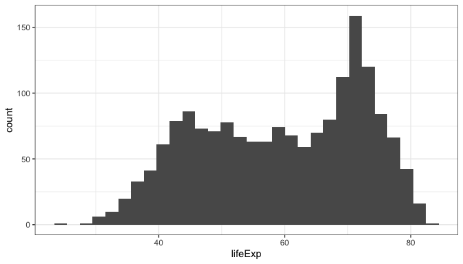

```r
# Life Expectancy
gapminder %>%
  ggplot(aes(lifeExp)) +
  geom_histogram(bins=30) +
  theme_bw()
```

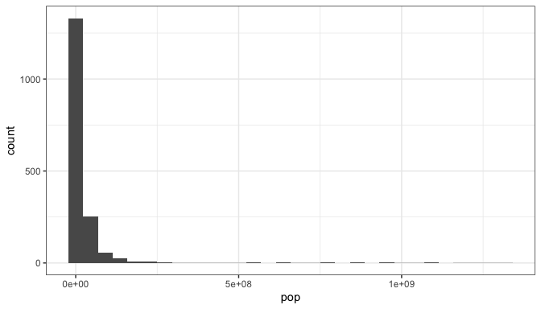

```r
# Population
gapminder %>%
  ggplot(aes(pop)) +
  geom_histogram(bins=30) +
  theme_bw()
```

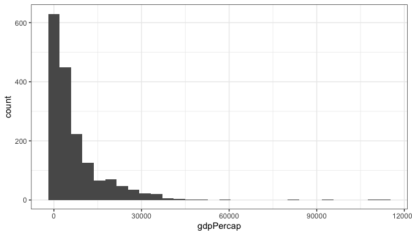

```r
# GDP
gapminder %>%
  ggplot(aes(gdpPercap)) +
  geom_histogram(bins=30) +
  theme_bw()
```

The better way is to plot all the functions at once using the `pivot_longer()` function from last time with `facet_wrap()`

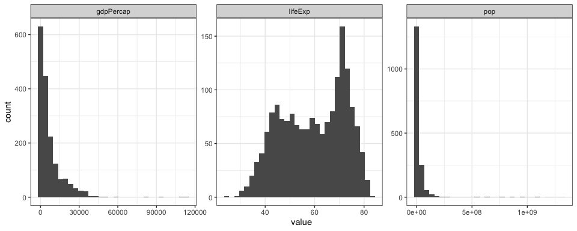

```r
gapminder %>%
  pivot_longer(cols=c(lifeExp,pop,gdpPercap)) %>%
  ggplot(aes(value)) +
  geom_histogram(bins=30) +
  facet_wrap(~name,scales="free") +
  theme_bw()
```

We can quickly see that there is large right skews in both `gdpPercap` and `pop`. Let’s transform these variables and re-plot.

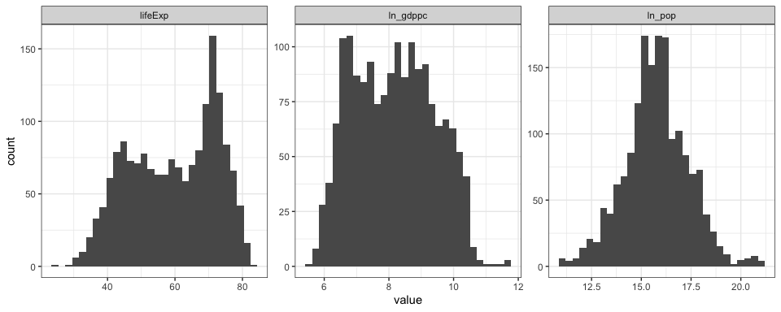

```r
gapminder %>%
  mutate(ln_pop = log(pop),
         ln_gdppc =  log(gdpPercap)) %>%
  pivot_longer(cols=c(lifeExp,ln_pop,ln_gdppc)) %>%
  ggplot(aes(value)) +
  geom_histogram(bins=30) +
  facet_wrap(~name,scales="free") +
  theme_bw()
```

Now let’s make things look professional!

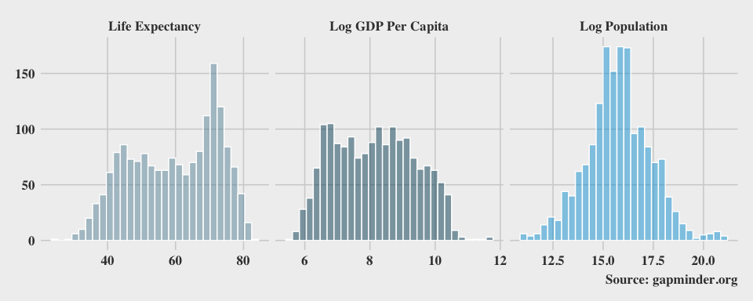

```r
gapminder %>%
  mutate(ln_pop = log(pop),
         ln_gdppc =  log(gdpPercap)) %>%
  pivot_longer(cols=c(lifeExp,ln_pop,ln_gdppc)) %>%
  mutate(name = case_when(
    name == "lifeExp" ~ "Life Expectancy",
    name == "ln_gdppc" ~ "Log GDP Per Capita",
    name == "ln_pop" ~ "Log Population"
  )) %>%
  ggplot(aes(value,fill=name)) +
  geom_histogram(bins=30,color="white",alpha=.5,show.legend = F) +
  facet_wrap(~name,scales="free_x") +
  labs(caption="Source: gapminder.org") +
  scale_fill_economist() +
  theme_fivethirtyeight() +
  theme(text=element_text(family="serif",face="bold",size=16))
```

#### 2. What’s the relationship between economic development and life expectancy? Is the relationship the same for all continents?

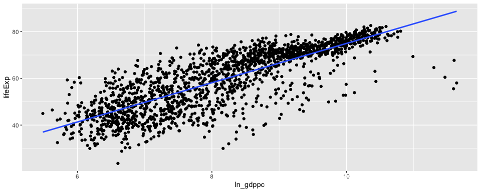

```r
gapminder %>%
  mutate(ln_pop = log(pop),
         ln_gdppc =  log(gdpPercap)) %>%
  ggplot(aes(ln_gdppc,lifeExp)) +
  geom_point() +
  geom_smooth(method = "lm",se=F) # Let's fit a line to the data.
```

Useful but there are a number of small aesthetic adjustments we could make to really help use distinguish between what is going on.

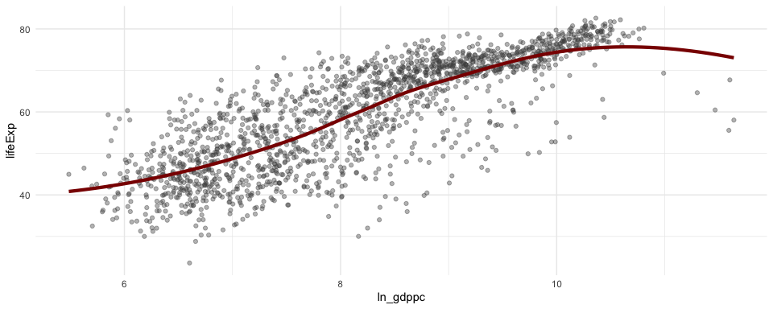

```r
gapminder %>%
  mutate(ln_pop = log(pop),
         ln_gdppc =  log(gdpPercap)) %>%
  ggplot(aes(ln_gdppc,lifeExp)) +
  geom_point(alpha=.4,color="grey30") +
  geom_smooth(method = "loess",se=F,color="darkred",size=1.5) +
  theme_minimal()
```

Is the trend the same by continent?

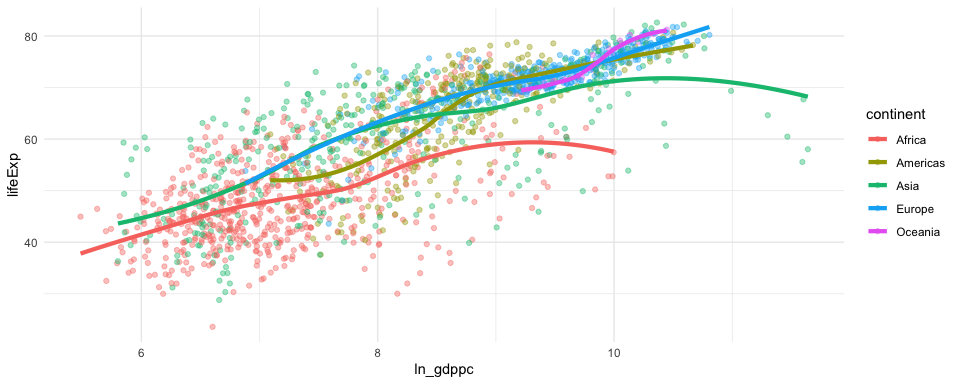

```r
gapminder %>%
  mutate(ln_pop = log(pop),
         ln_gdppc =  log(gdpPercap)) %>%
  ggplot(aes(ln_gdppc,lifeExp,color=continent)) +
  geom_point(alpha=.4,) +
  geom_smooth(method = "loess",se=F,size=1.5) +
  theme_minimal()
```

Generally speaking, it appears so, but it’s difficult to hone in on any one continent. There is just a lot going on. Let’s consider two alternative ways of presenting this same data.

Way 1: separate plots using `facet_`

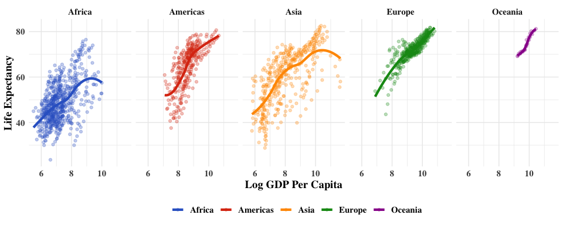

```r
gapminder %>%
  mutate(ln_pop = log(pop),
         ln_gdppc =  log(gdpPercap)) %>%
  ggplot(aes(ln_gdppc,lifeExp,color=continent)) +
  geom_point(alpha=.3,) +
  geom_smooth(method = "loess",se=F,size=1.5) +
  facet_wrap(~continent,nrow=1) +
  labs(x="Log GDP Per Capita",y = "Life Expectancy",color="") +
  scale_color_gdocs() +
  theme_minimal() +
  theme(legend.position = "bottom",
        text = element_text(size=14,family="serif",face="bold"))
```

Way 2: Plot the trends but not the individual data points

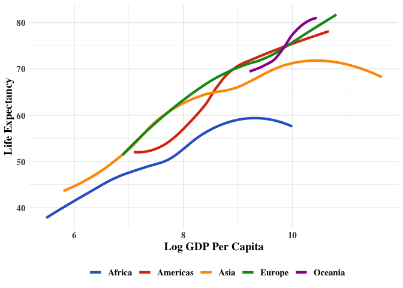

```r
gapminder %>%
  mutate(ln_pop = log(pop),
         ln_gdppc =  log(gdpPercap)) %>%
  ggplot(aes(ln_gdppc,lifeExp,color=continent)) +
  geom_smooth(method = "loess",se=F,size=1.5) +
  labs(x="Log GDP Per Capita",y = "Life Expectancy",color="") +
  scale_color_gdocs() +
  theme_minimal() +
  theme(legend.position = "bottom",
        text = element_text(size=14,family="serif",face="bold"))
```

#### 3. Which countries in Africa have the lowest levels of life expectancy?

Two ways we could go about answering a question like this. The first might just be an ordered barplot. Here we might rephrase the question as: “Which countries in Africa have the lowest levels of life expectancy *on average*?”

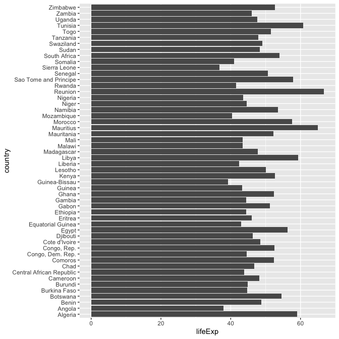

```r
gapminder %>%
  filter(continent == "Africa") %>%
  group_by(country) %>%
  summarize(lifeExp = mean(lifeExp),.groups="drop") %>%
  ggplot(aes(lifeExp,country)) +
  geom_col()
```

Nice, but ordering the factor fields would go a long way. Doing so is easy using the tidy `forcats` package (which is part of the tidyverse), and why we’re at it, lets’ add a little polish.

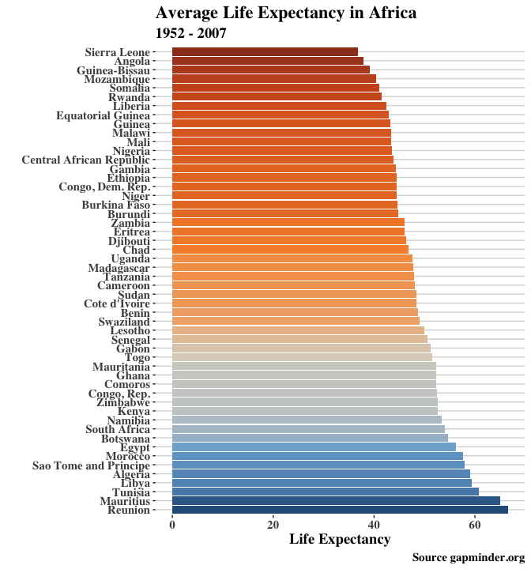

```r
gapminder %>%
  filter(continent == "Africa") %>%
  group_by(country) %>%
  summarize(lifeExp = mean(lifeExp),.groups="drop") %>%
  ggplot(aes(lifeExp,fct_reorder(country,desc(lifeExp)),fill=lifeExp)) +
  geom_col(show.legend = F) +
  scale_fill_gradient2_tableau() +
  labs(x="Life Expectancy",y="",
       title = "Average Life Expectancy in Africa",
       subtitle = "1952 - 2007",
       caption = "Source gapminder.org") +
  theme_hc() +
  theme(text=element_text(family = "serif",face="bold",size=14))
```

Another way we could approach this is to lay everything out spatially. ggplot with the `maps` package provides a useful way to extract map data on the fly.

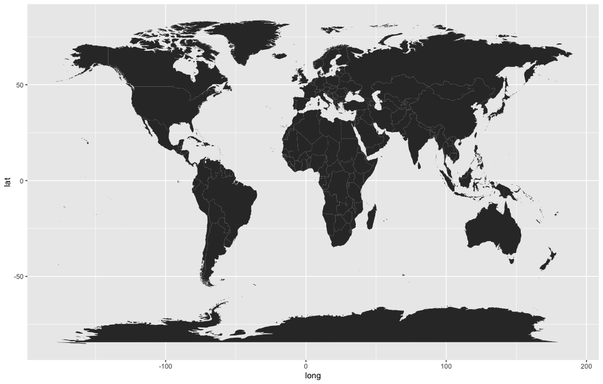

```r
map_data("world") %>%
  ggplot(aes(x=long,y=lat,group=group)) +
  geom_polygon()
```

Our focus is the African continent, so we’ll just focus on that portion of the data using the data wrangling principals.

```r
# Simplify the map data
world <-
  map_data("world") %>%
  select(long,lat,group,country=region) %>%

  # Again standardize the country names
  mutate(country = countrycode::countrycode(country,"country.name","country.name")) %>%
  mutate(country = ifelse(country == "South Sudan","Sudan",country))

# subset the relevant African countries in the data.
africa <-
  gapminder %>%
  filter(continent == "Africa") %>%
  group_by(country) %>%
  summarize(lifeExp = mean(lifeExp),.groups="drop")  %>%
  mutate(country = countrycode::countrycode(country,"country.name","country.name")) %>%
  inner_join(world,by="country")
```

Let’s plot the map.

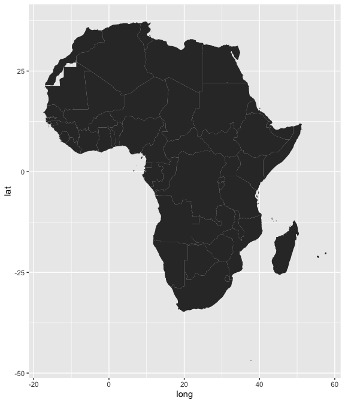

```r
africa %>%
  ggplot(aes(x=long,y=lat,group=group)) +
  geom_polygon()
```

Now let’s fill in the fields on the map using the average life expectancy values.

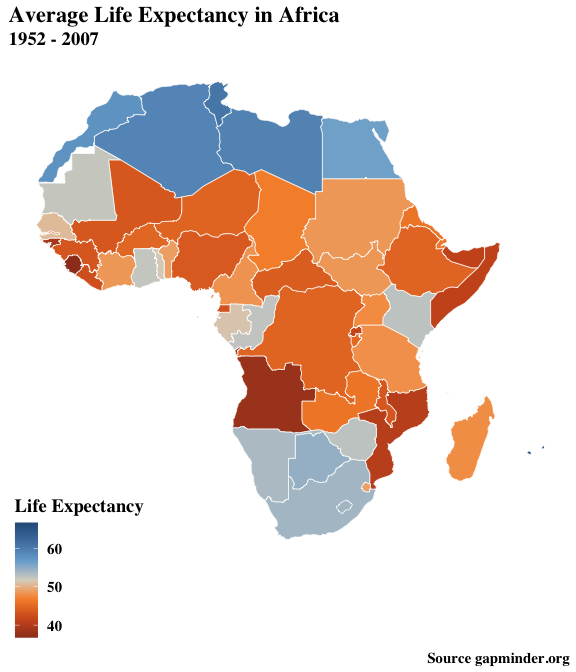

```r
africa %>%
  ggplot(aes(x=long,y=lat,group=group,fill=lifeExp)) +
  geom_polygon(color="white",size=.25) +
  scale_fill_gradient2_tableau() +
  theme_map() +
  labs(fill="Life Expectancy",
       title = "Average Life Expectancy in Africa",
       subtitle = "1952 - 2007",
       caption = "Source gapminder.org") +
  theme(text=element_text(family = "serif",face="bold",size=14))
```

What if we wanted to look at how these spatial patterns shifted over time? Not a problem, we just need to tweak the data and plot code a little bit.

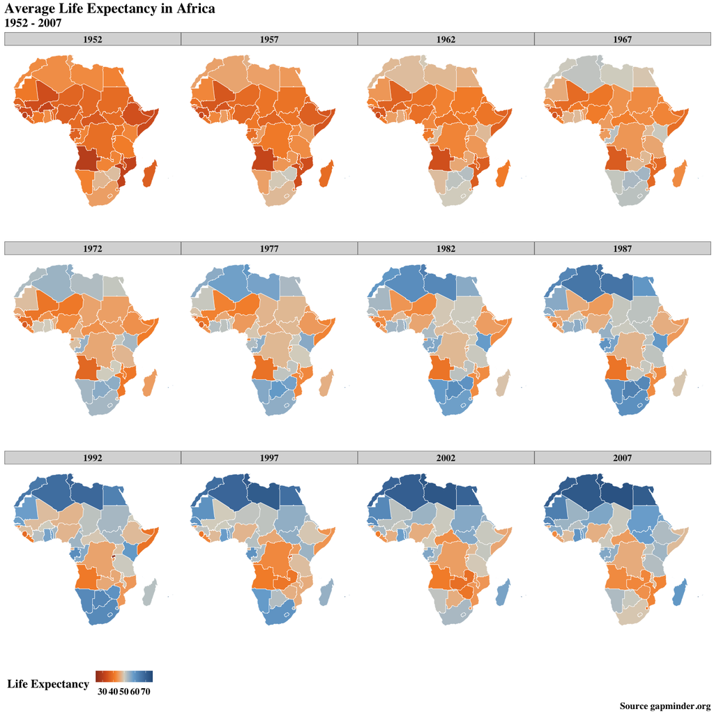

```r
# DON'T aggregate the lifeExp variable this time.
gapminder %>%
  filter(continent == "Africa") %>%
  mutate(country = countrycode::countrycode(country,"country.name","country.name")) %>%
  inner_join(world,by="country") %>%
  ggplot(aes(x=long,y=lat,group=group,fill=lifeExp)) +
  geom_polygon(color="white",size=.25) +
  scale_fill_gradient2_tableau() +
  theme_map() +
  labs(fill="Life Expectancy",
       title = "Average Life Expectancy in Africa",
       subtitle = "1952 - 2007",
       caption = "Source gapminder.org") +
  facet_wrap(~year) +
  theme(text=element_text(family = "serif",face="bold",size=18),
        legend.position = "bottom")
```